# KEY: Themes, Colors, and Accessibility: Per-Child Spending Growth by State

Author

Fabulous Student

Published

October 13, 2026

> **INSTRUCTOR KEY.** Every student-facing blank is filled in below. Student choices (theme, palette, colors) are one valid option among many. The sample responses in Step 7 are suggested answers based on what these choices typically produce, so check them against your own render.

## Introduction

In this activity, you will take a scatterplot comparing each state’s per-child PreK-12 spending in 1997 to its spending in 2016 (the `tidykids` dataset) and work through three things we covered today:

1. **Theme:** apply a theme from a theme package, then customize it with `theme()`
2. **Color:** apply a discrete palette and (if time allows) a continuous palette
3. **Accessibility:** run your plots through {colorblindr} and decide what/if you would change for accessibility

The data wrangling and the base plots are **already done for you**. Step 1 is setup, Step 2 is done for you, Step 3 is where the assignment really begins!

Resources you will/may need:

- [`theme()` cheatsheet](https://bookdown.org/alapo/learnr/images/ggplot_elements2.png)
- [`theme()` documentation](https://ggplot2.tidyverse.org/reference/theme)
- [{ggthemes}](https://jrnold.github.io/ggthemes/), [{pilot}](https://github.com/olihawkins/pilot), [{hrbrthemes}](https://github.com/hrbrmstr/hrbrthemes)
- [MetBrewer documentation](https://github.com/BlakeRMills/MetBrewer)
- [viridis documentation](https://ggplot2.tidyverse.org/reference/scale_viridis.html)
- [{colorblindr}](https://github.com/clauswilke/colorblindr)

## Step 1: Load Libraries and Data

Not every package is on CRAN! {pilot} and {colorblindr} are installed from GitHub with `{remotes}`. If you do not have them yet, run the commented lines **once** in your console (not in this document).

```r
# Run these once in the console if needed:
# install.packages("remotes")
# install.packages("ggthemes")
# install.packages("hrbrthemes")
# install.packages("MetBrewer")
# remotes::install_github("olihawkins/pilot")
# remotes::install_github("clauswilke/colorblindr")

# Required: {tidyverse} (reading and wrangling) and {colorblindr} (Step 5). Everything else is your choice.
library(tidyverse)
library(colorblindr)
library(ggthemes)
library(pilot)
library(hrbrthemes)
library(MetBrewer)
```

```r
# Read in your data
tidykids <- read_csv("week-8/tidykids.csv")
```

## Step 2: Wrangle the Data and Build the Base Plots (Already Completed For You)

We filter to PK12ed spending in 1997 and 2016, reshape the data so each state has one row with a column for each year, calculate the percent change between the two years (`pct_change`), and create a `region` variable. Then we build two **base plots** with no theme and the default colors. Each point is a state, and the dashed line marks “no change” (points above it spent more in 2016 than in 1997):

- `p_discrete`: points colored by `region` (a **discrete** variable)
- `p_continuous`: points colored by `pct_change` (a **continuous** variable)

```r
tidykids_plot <- tidykids |>
  filter(expenditure == "PK12ed", year %in% c(1997, 2016)) |>
  select(state, year, inf_adj_perchild) |>
  pivot_wider(
    names_from = year,
    values_from = inf_adj_perchild,
    names_prefix = "spend_"
  ) |>
  mutate(
    pct_change = (spend_2016 - spend_1997) / spend_1997 * 100,
    region = case_when(
      state %in%
        c(
          "Maine",
          "New Hampshire",
          "Vermont",
          "Massachusetts",
          "Rhode Island",
          "Connecticut",
          "New York",
          "New Jersey",
          "Pennsylvania"
        ) ~ "Northeast",
      state %in%
        c(
          "Ohio",
          "Indiana",
          "Illinois",
          "Michigan",
          "Wisconsin",
          "Minnesota",
          "Iowa",
          "Missouri",
          "North Dakota",
          "South Dakota",
          "Nebraska",
          "Kansas"
        ) ~ "Midwest",
      state %in%
        c(
          "Delaware",
          "Maryland",
          "Virginia",
          "West Virginia",
          "North Carolina",
          "South Carolina",
          "Georgia",
          "Florida",
          "Kentucky",
          "Tennessee",
          "Alabama",
          "Mississippi",
          "Arkansas",
          "Louisiana",
          "Oklahoma",
          "Texas",
          "District of Columbia"
        ) ~ "South",
      state %in%
        c(
          "Montana",
          "Idaho",
          "Wyoming",
          "Colorado",
          "New Mexico",
          "Arizona",
          "Utah",
          "Nevada",
          "California",
          "Oregon",
          "Washington",
          "Hawaii",
          "Alaska"
        ) ~ "West"
    )
  )
```

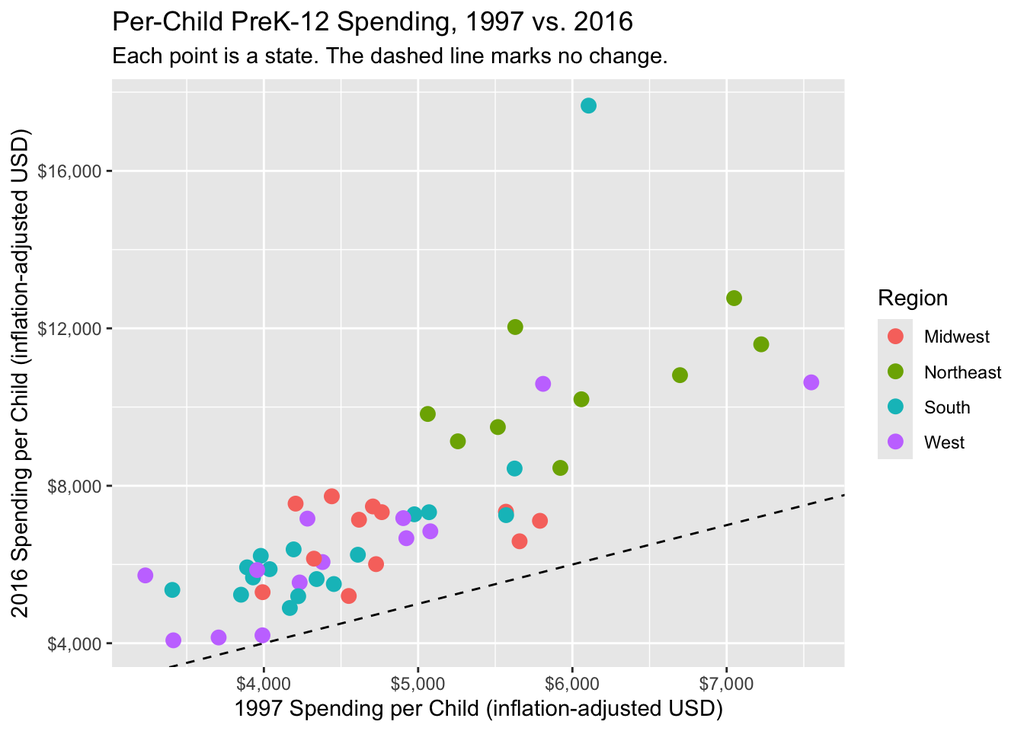

```r
p_discrete <- tidykids_plot |>
  ggplot(aes(x = spend_1997, y = spend_2016, color = region)) +
  geom_abline(slope = 1, intercept = 0, linetype = "dashed") +
  geom_point(size = 3) +
  scale_x_continuous(labels = scales::dollar) +
  scale_y_continuous(labels = scales::dollar) +
  labs(
    title = "Per-Child PreK-12 Spending, 1997 vs. 2016",
    subtitle = "Each point is a state. The dashed line marks no change.",
    x = "1997 Spending per Child (inflation-adjusted USD)",
    y = "2016 Spending per Child (inflation-adjusted USD)",
    color = "Region"
  )

p_continuous <- tidykids_plot |>
  ggplot(aes(x = spend_1997, y = spend_2016, color = pct_change)) +
  geom_abline(slope = 1, intercept = 0, linetype = "dashed") +
  geom_point(size = 3) +
  scale_x_continuous(labels = scales::dollar) +
  scale_y_continuous(labels = scales::dollar) +
  labs(
    title = "Per-Child PreK-12 Spending, 1997 vs. 2016",
    subtitle = "Each point is a state. The dashed line marks no change.",
    x = "1997 Spending per Child (inflation-adjusted USD)",
    y = "2016 Spending per Child (inflation-adjusted USD)",
    color = "% change"
  )

p_discrete
```

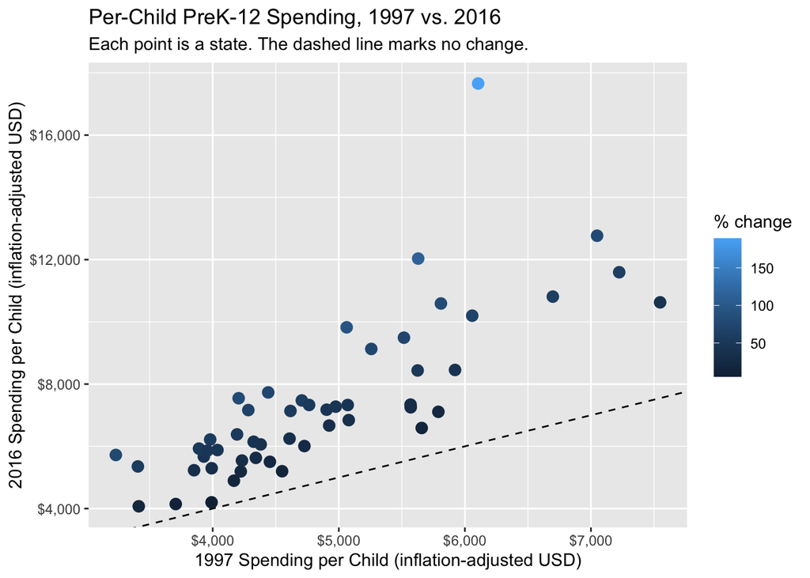

```r
p_continuous
```

## Step 3: Apply a Theme and Customize It (Plot A)

**Part 1: Pick a theme.** Choose **at least one** theme from {ggthemes}, {pilot}, or {hrbrthemes} and add it to `p_discrete`. Try a couple! Then keep the one you like best for the rest of the activity.

Some options from [{ggthemes}](https://jrnold.github.io/ggthemes/): `theme_tufte()`, `theme_solarized()`, `theme_excel()`

Some options from [{pilot}](https://github.com/olihawkins/pilot): `theme_pilot()`

Some options from [{hrbrthemes}](https://github.com/hrbrmstr/hrbrthemes):`theme_ipsum()`, `theme_ipsum_archivo()`, `theme_ipsum_es()`, `theme_ipsum_gs()`, `theme_ipsum_ps()`, `theme_ipsum_pub()`, `theme_ipsum_rc()`, `theme_ipsum_tw()`, `theme_modern_rc()`, `theme_ft_rc()`

> *Note:* `theme_ipsum_*()` requires the font you choose to be installed on your system. If you get font warnings, use `theme_ipsum()` or a different `theme_ipsum_*()` choice instead.

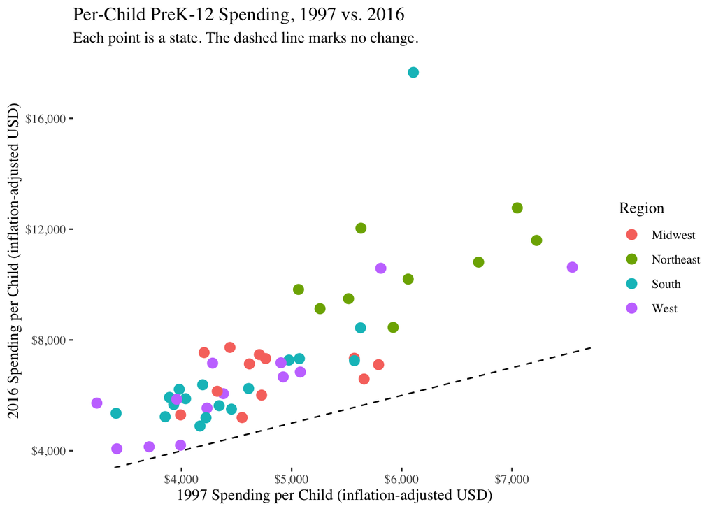

```r
# Try adding one or more themes to p_discrete and p_continuous here. Which one do you like best?
# Don't store anything to the plots yet. You'll choose your favorite theme and do that below. For now, think of this as an experimental code block!

# Ex: p_discrete + theme_tufte()
p_discrete + theme_tufte()
```

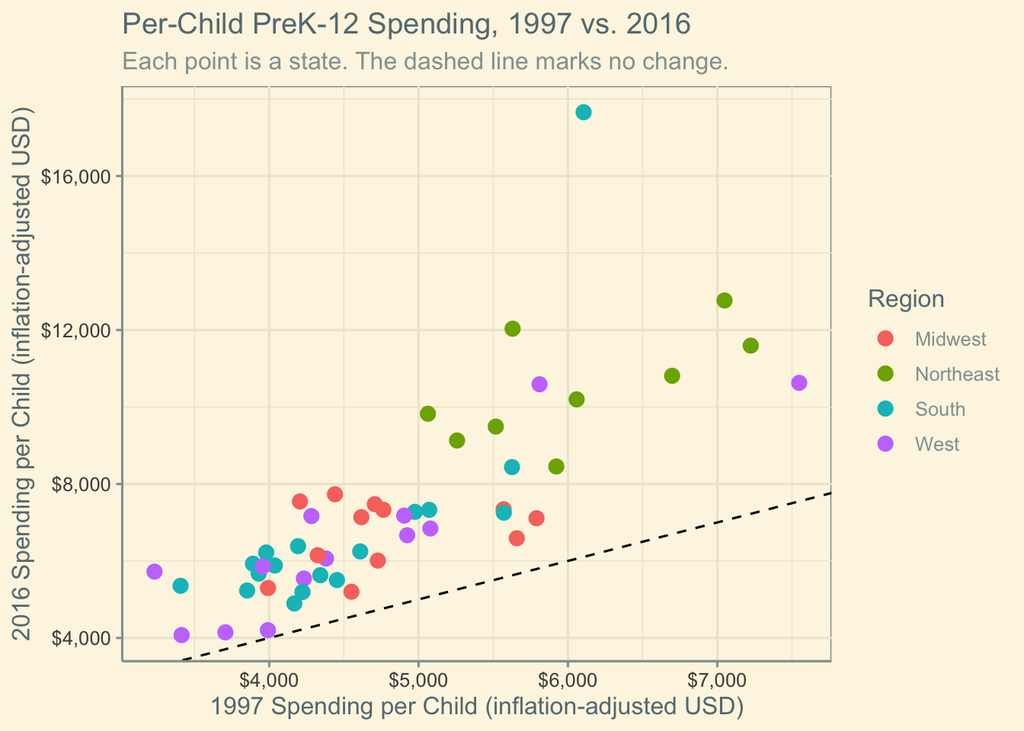

```r
p_discrete + theme_solarized()
```

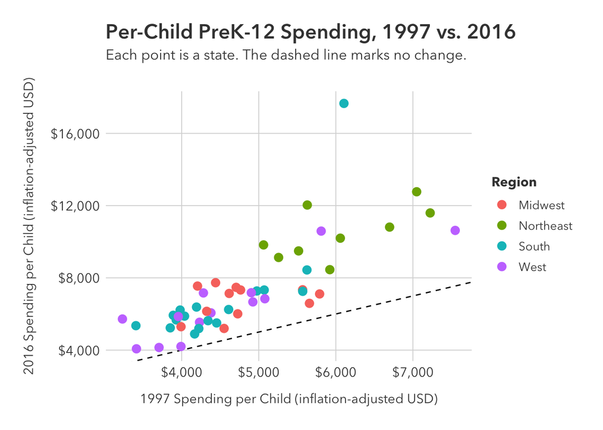

```r
p_discrete + theme_pilot()
```

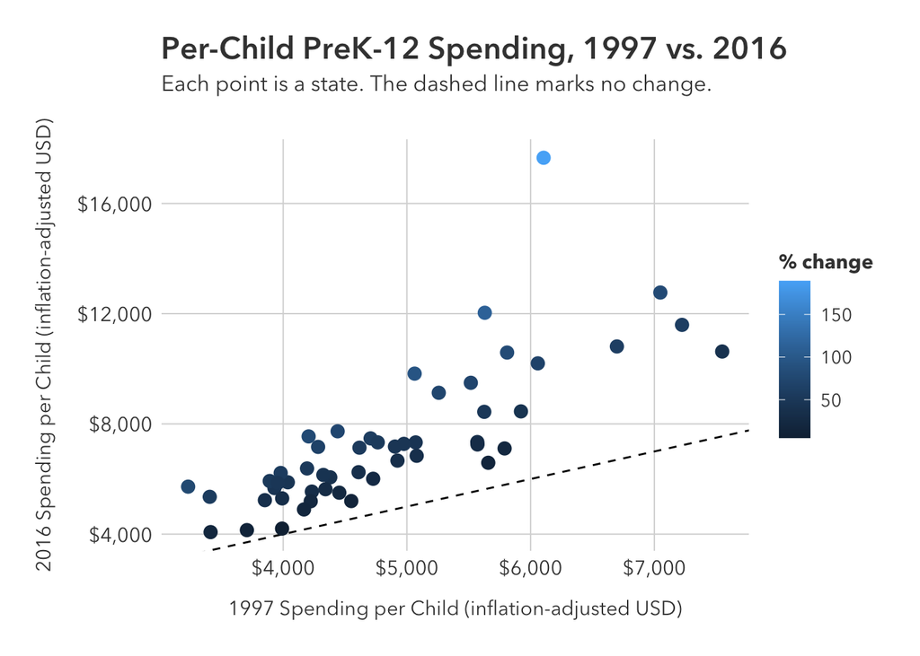

```r
# theme_ipsum() works too if the font is available:
# p_discrete + theme_ipsum()

# Themes work on the continuous plot as well:
p_continuous + theme_pilot()
```

**Part 2: Customize with `theme()`.** Store your customizations in an object called `my_theme` so we can reuse it later. I filled in the first one as an example. Add the rest:

- Make the title size 18 and bold *(done for you)*
- Move the legend to the bottom of the plot
- Remove the minor gridlines
- Change the plot background to a color of your choosing
- Change the major gridlines to a color of your choosing

*Hint:* you will want `legend.position`, `panel.grid.minor`, `plot.background`, and `panel.grid.major`.

```r
my_theme <- theme(
  plot.title = element_text(size = 18, face = "bold"),
  legend.position = "bottom",
  panel.grid.minor = element_blank(),
  plot.background = element_rect(fill = "#F5F5F5", color = NA),
  panel.grid.major = element_line(color = "grey70")
)
```

**Part 3: Put it together.** Add your theme (Step 3, Part 1) and then `my_theme` (Step 3, Part 2) to `p_discrete`, and save the result as `plot_a`.

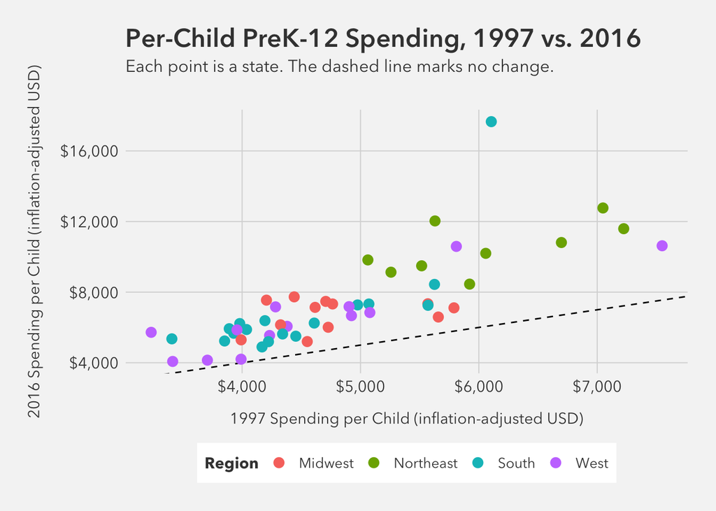

```r
plot_a <- p_discrete + theme_pilot() + my_theme

plot_a
```

*Order matters!* `my_theme` goes **after** the pre-built theme. What would happen if you flipped them? Try it and see.

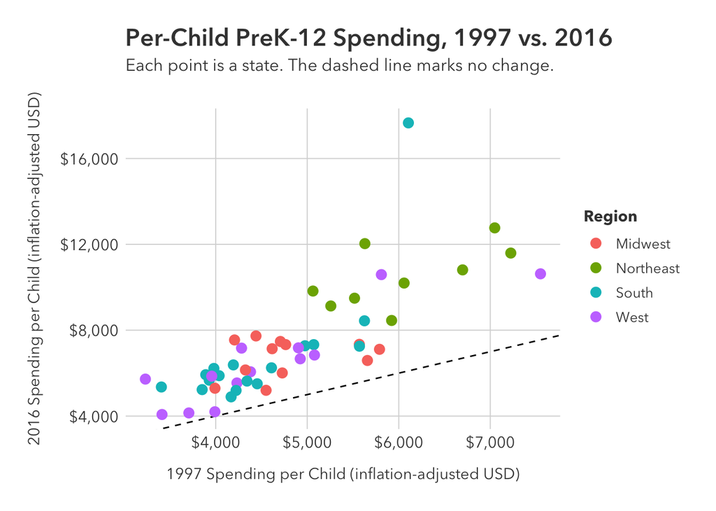

```r
# my_theme first, then the pre-built theme
p_discrete + my_theme + theme_pilot()
```

**Response:** The customizations are lost (or mostly lost). `theme_pilot()` is a *complete* theme, so when it comes second it resets the elements that `my_theme` had just set: the title goes back to the theme’s default style, the legend moves back to its default position, and so on. Themes are applied in order, and the last one added wins. Customize **after** the pre-built theme.

## Step 4: Apply a Discrete Color Palette (Plot B)

Now let’s override the default colors on `plot_a`. Choose **one**:

- {MetBrewer}: `scale_color_manual(values = met.brewer("PaletteName"))`
- viridis: `scale_color_viridis_d(option = "...")`
- {ggthemes}: [several options](https://jrnold.github.io/ggthemes/): most themes ship with corresponding color palette
- {pilot}: has `scale_color_pilot()`
- {hrbrthemes}: has `scale_color_ipsum()`,`scale_color_ft()`, `scale_color_bit12()`

**Try Several:** apply several, but in the end, choose one.

Store your result as `plot_b`.

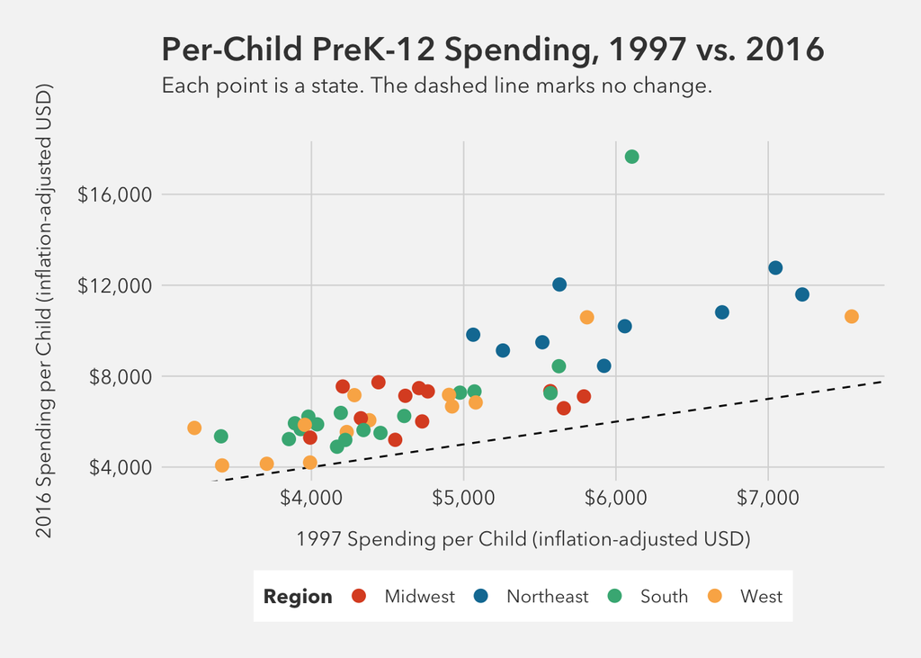

```r
# MetBrewer's Egypt palette has exactly 4 colors, one for each region
plot_b <- plot_a +
  scale_color_manual(values = met.brewer("Egypt"))

plot_b
```

```r
# Other valid options to try:
# plot_a + scale_color_viridis_d(option = "D")
# plot_a + scale_color_pilot()
```

## Step 5: Accessibility Check on Plots A and B

Run `plot_a` (default colors) and `plot_b` (your palette) through `cvd_grid()`. This shows how each plot looks to people with different types of color vision deficiency.

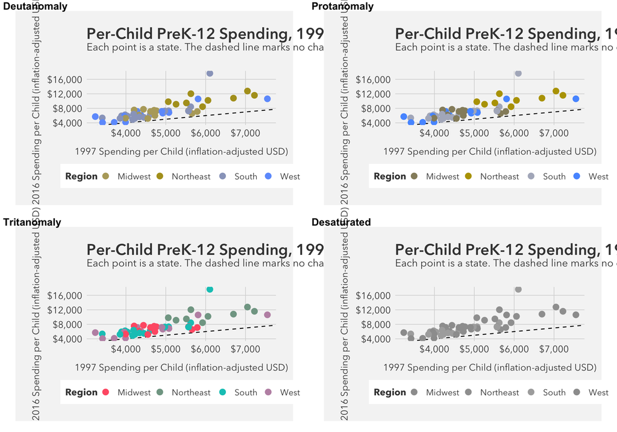

```r
cvd_grid(plot_a)
```

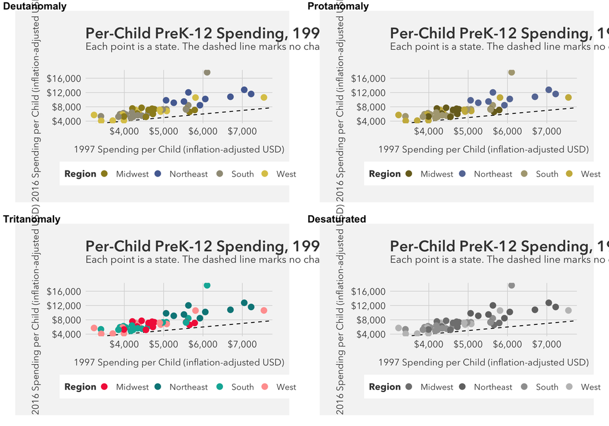

```r
cvd_grid(plot_b)
```

## Step 6 (Stretch): Apply a Continuous Color Palette (Plot C)

This time, start from `p_continuous` (color is mapped to `pct_change`, a continuous variable). Add your same theme and `my_theme`, then add a **continuous** viridis palette using `scale_color_viridis_c()`. Try different `option`s (A-H) and pick one. Save the result as `plot_c`, then run it through `cvd_grid()`.

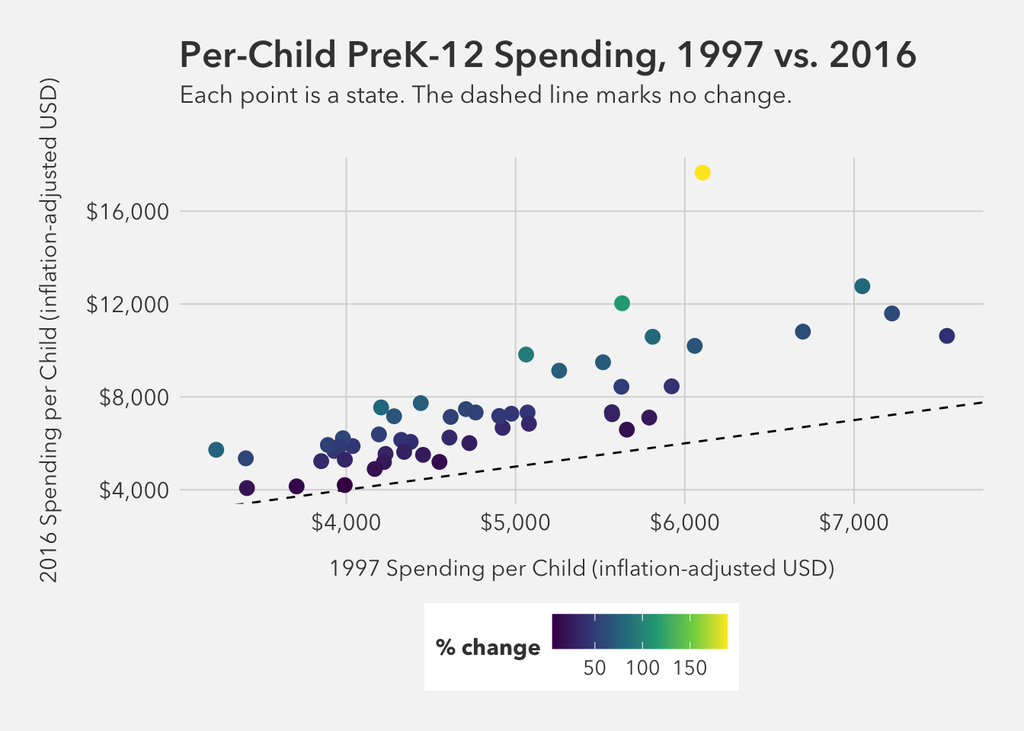

```r
plot_c <- p_continuous +
  theme_pilot() +
  my_theme +
  scale_color_viridis_c(option = "D")

plot_c
```

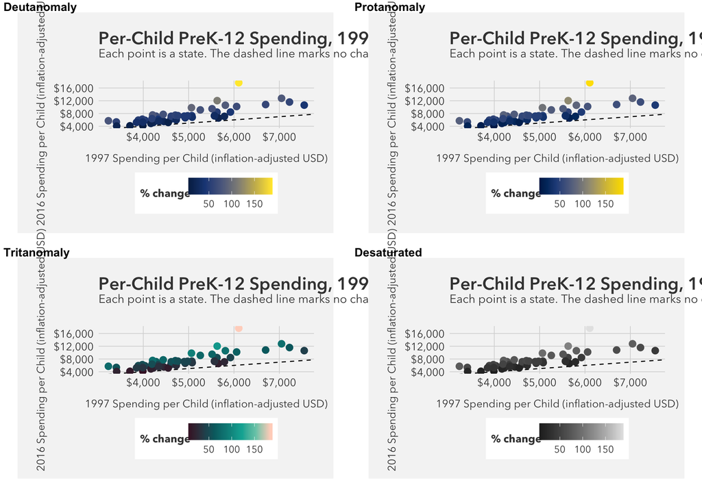

```r
cvd_grid(plot_c)
```

## Step 7: Discuss and Decide

Talk with your group, then write a short response to each question. **Everyone should be able to point to something specific on the plots.**

**1. Which plot (A, B, or C if you did it) is hardest to read in the `cvd_grid()` output? Which panel (deuteranomaly, protanomaly, tritanomaly, desaturated) is the worst for it, and why?**

**Sample response:** Plot A (the default ggplot2 colors) is the hardest to read. The default red and green hues are the problem. In the deuteranomaly and protanomaly panels they become nearly the same muddy olive/tan, so two regions are hard to tell apart, and in the desaturated panel several regions look like similar grays. Plot B (Egypt) is better, but its red-orange and green can still be close in the red-green panels.

**2. Which plot would you choose to share with an audience, and why?**

**Sample response:** Plot B, with a note. The Egypt palette holds up better across the `cvd_grid()` panels than the default colors, and the legend at the bottom keeps the plot area clean. If this plot were going in front of an audience, I would still not rely on color alone (see question 3).

**3. Name at least one specific tweak you would make to improve accessibility (e.g., a different palette or `option`, larger points, different point shapes with `shape = region`, direct labels instead of a legend, a lighter background). Why would it help?**

**Sample response:** Add `shape = region` so each region has its own point shape in addition to its color. Then the regions can still be told apart when two colors look alike. Other good answers: swap in a palette designed for color-vision deficiency (e.g., a viridis option or a MetBrewer palette marked colorblind-friendly), or label the outlying points directly (D.C., for example) instead of relying on the legend.

## Bonus: Test Your Tweak

If you have time, make the tweak you described in question 3. Save the new plot as `plot_fixed` and run it through `cvd_grid()`. Did it help?

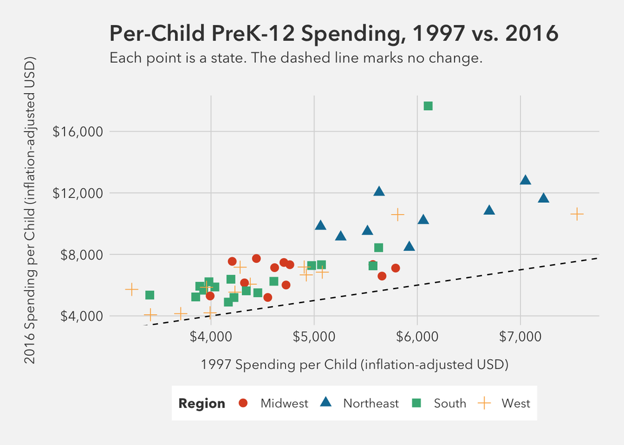

```r
# Map shape to region too, so color is no longer the only cue.
# (Adding another geom_point() would draw a second layer of points on top.)
plot_fixed <- plot_b +
  aes(shape = region) +
  labs(shape = "Region") # same title as color so the legends merge

plot_fixed
```

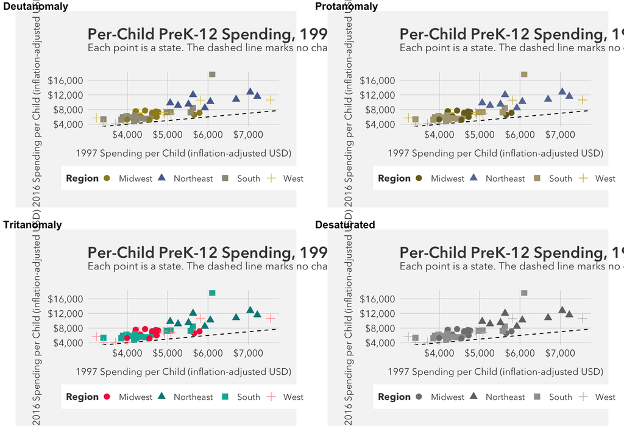

```r
cvd_grid(plot_fixed)
```